# 奇瑞汽车发展史：一家芜湖小厂如何成为中国汽车出海的压舱石

更新日期：2026年5月26日

2026年5月24日

打开任意一份中国乘用车销量榜，奇瑞几乎从未坐上头把交椅。它没有比亚迪的电动化光环，没有吉利的资本故事，也没有长城那种被反复讨论的”硬派形象”。但如果你把同一份销量榜换成出口榜，再换成”中国品牌走出去”的研究材料，奇瑞会突然出现在所有故事的最前面，并且一坐就是 22 年。

这种”国内安静、海外炸裂”的反差并不是偶然。它由三股力量长期咬合的结果：一家被迫从地方政府体制里挤出来的小厂，一条”先难市场练手、再回头打主流市场”的出海路径，和一套不断被迫升级的品牌矩阵。

这份教程把奇瑞 1997 到 2026 年的关键节点拆开来讲：公司怎么起步、车型怎么演进、出海怎么从 10 辆叙利亚订单走到 114 万辆年出口，以及现在站在哪个十字路口。读完之后，你应该能在脑子里画出一张”奇瑞地图”，并且能用这张地图理解任何一家中国制造业公司的全球化路径。

> **本教程会覆盖**：1997 年建厂、第一辆车风云、QQ 现象、与 Jaguar Land Rover 的合资、EXEED / Omoda / Jaecoo / iCar / Fulwin 多品牌矩阵、俄罗斯/巴西/欧洲三种打法、10+ 座海外工厂、2024 年 260 万辆全球销量与退出俄罗斯的合规故事，以及可迁移给其他出海公司的四层飞轮模型。

## 第1章 为什么应该认识奇瑞

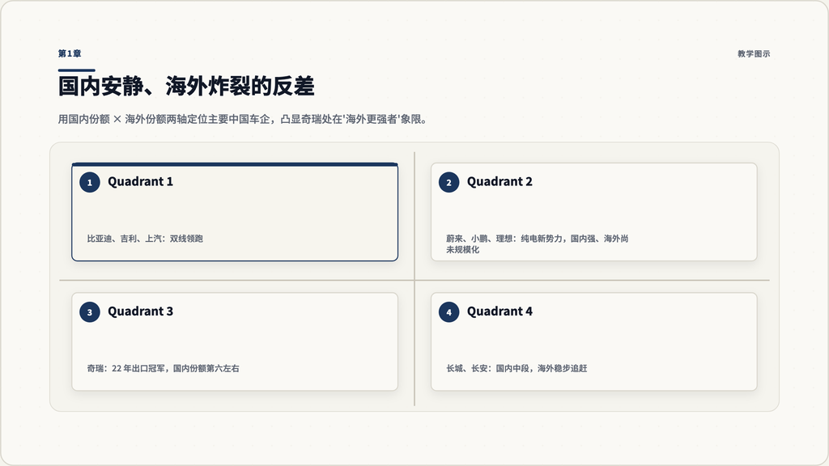

第1章：国内安静、海外炸裂的反差

### 1.1 反差锚点：销量榜上看不见，出口榜上反复出现

中国汽车产业的注意力曲线被三家公司主导：比亚迪靠纯电、吉利靠资本运作和并购、长城靠硬派 SUV 与皮卡。在 2024 年的国内乘用车销量榜上，奇瑞位列第六左右，远低于比亚迪和上汽，是”知道但不显眼”的位置。

但是，把视角切换到出口榜，画面立刻反转：

- 2024 年全年，奇瑞集团出口 1,144,588 辆，同比增长 21.4%。
- 这是奇瑞**连续第 22 年**位居中国品牌乘用车出口第一。
- 截止 2025 年中，奇瑞成为**首个累计出口超过 500 万辆**的中国车企。
- 海外用户数已超过 450 万。
- 业务覆盖 110 多个国家和地区。

也就是说，在过去 20 年里，每当中国汽车谈出海，统计图表的”中国品牌出口第一”这一格，几乎一直贴着同一个 logo。

### 1.2 学习者会卡在哪儿

很多人接触奇瑞时会陷入一个典型的认知错配：“这家公司没有什么明星车型，怎么能卖那么多到海外？”这个问题背后，藏着一个关于”中国出海”的误解：

很多人默认全球化路径是”先在国内成为冠军，再带着国内成功复制出海”。这条路径对应的是手机行业的小米、互联网公司的 TikTok。

奇瑞走的不是这条路。它是**先用低价、低技术门槛、低品牌包袱的车攻入新兴市场，用海外现金流和工厂规模反哺国内**。这种顺序在制造业出海里非常少见，也是这门课的真正主题。

### 1.3 一张图理解奇瑞的位置

如果把所有主要中国乘用车品牌画在一张”国内市占份额 × 海外销量份额”的二维矩阵上：

- 比亚迪、吉利、上汽集团：国内份额高，海外份额开始追赶。
- 长城、长安：国内中等份额，海外份额中等。
- 奇瑞：**国内份额中等，海外份额绝对领先**。
- 一些纯电新势力（蔚来、小鹏、理想）：国内份额可观，海外份额几乎为零。

### 1.4 这一章你要带走的三件事

- 奇瑞是中国出口体量最大、年限最长的车企，22 年第一、累计 500 万辆+。
- 这种结果不是国内冠军的副产品，而是另一条独立的全球化路径。
- 这条路径有它自己的代价，包括”在国内被忽视”的长期心智位置，和后面我们会反复讨论的合规与品牌升级压力。

### 1.5 自检题

试着不打开搜索，回答下面三个问题：

1. 你能说出两个奇瑞海外卖得很好、但你在国内几乎没听说过的品牌吗？
2. 在你印象里，“中国车出口第一”通常被归功于谁？这个印象和事实差多远？
3. 你认识一个真实的中国出海企业，它的路径更像奇瑞，还是更像比亚迪？为什么？

如果三个问题里有两个让你觉得”答不上来”，请继续往下读。

## 第2章 创业基因：芜湖小厂的 5 年（1997-2001）

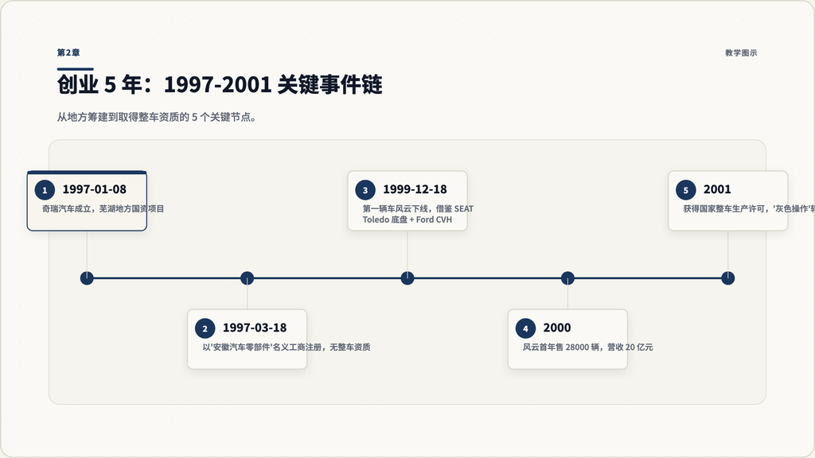

第2章：1997-2001 创业关键事件链

### 2.1 一个被低估的起点：1997-01-08

奇瑞汽车的官方成立日期是 1997 年 1 月 8 日。地点是安徽省芜湖市，一个长江中下游的地级市，既不是上海这样的传统汽车工业重镇，也不是后来的”汽车特区”广州、重庆。

这一点决定了奇瑞早期的所有动作：先得活下来，先得造出车，再去想批文。

### 2.2 关键人物：尹同跃和”前一汽工程师”团队

奇瑞早期最关键的人物是尹同跃。他原本在一汽-大众工作过，是装配车间的工程师。1996 年，他被聘为奇瑞的技术负责人。他带来的不是某一种特定的造车技术，而是**一种把工程问题拆解到节点的工厂方法**。

奇瑞的创业团队里有不少类似背景的人：在合资工厂工作过、见过现代汽车工厂的标准化生产是什么样子、但又有强烈的”自己造车”动机。这个人才组合，在 1990 年代末的中国非常稀缺。

### 2.3 第一辆车：风云 Fengyun（1999）

1999 年 12 月 18 日，奇瑞的第一辆车——风云——下线。这辆车在技术上完全可以被叫做”拼装产物”：

- 底盘是 SEAT Toledo 的未授权复制版。
- 发动机用的是 Ford CVH。
- 整车造型沿用了 1990 年代欧洲 B 级车的设计语言。

这种”拼装”在当时不是耻辱，而是必经之路。整车开发能力中国还没有，只能先用现有平台拼出一辆能跑的车，建立起整条供应链和制造能力。

风云的出厂价控制在 10 万元人民币以内。在 1999-2000 年的中国市场，10 万元以下的可上牌轿车几乎是空白。**风云第一年就卖出了 28,000 辆，营收 20 亿元**。这是奇瑞第一次拿到正现金流。

### 2.4 拿到准生证：2001 年的官方批文

虽然风云已经在卖，但奇瑞在 1999-2000 年其实并没有拿到全国乘用车的生产资质，处在”灰色地带”。2001 年，奇瑞终于获得国家颁发的整车生产许可证。

这件事的意义远比账面上的”一张证”重要：

- 它意味着风云可以堂堂正正进入全国销售渠道。
- 它打开了出口资质的可能性——出口需要被国家认可的整车厂身份。
- 它确认了”地方国资 + 灰色操作 + 后置合法化”这条路径在 1990 年代末的中国是可行的。

### 2.5 在芜湖的好处与代价

把工厂放在芜湖，对早期奇瑞来说有两个隐藏优势：

- 第一，地方政府愿意把”汽车作为本地支柱产业”的政治意愿压上去，这意味着土地、税收、人才补贴的稳定支持。
- 第二，远离北京、上海、广州的产业聚光灯，让奇瑞在不引人注目的状态下完成了第一个 5 年的”野蛮生长”。

代价同样存在：芜湖没有现成的汽车产业链人才池，几乎所有早期工程师都需要从外地挖；本地缺乏顶级研究机构，导致后来在新能源、智能化转型时，奇瑞总是要花更大代价”补人才”。

### 2.6 这一章你要注意的细节

- **创业方式**：不是大集团内部孵化，也不是民企从零起步，而是”地方政府 + 工程师团队 + 灰色资质”的第三条路。
- **第一辆车定位**：风云不是技术杰作，是一辆**让公司活下来的车**。它的真正价值是建立现金流和供应链。
- **资质取得节奏**：先造车、再合法化，是 1990 年代末-2000 年代初中国制造业典型的”非线性”做法。

### 2.7 把”先做后合规”映射到你熟悉的公司

请用两段话写下：

1. 如果你是 1998 年的奇瑞投资人，你会反对哪一项决定？为什么？
2. 你认识的中国出海公司里，有没有谁的早期路径有类似”先做后合规”的特征？这给它后来的国际化带来了什么影响？

## 第3章 第一次规模化：风云、QQ、Tiggo（2002-2010）

[figure not shown]

第3章：风云、QQ、Tiggo 三车撬开三段市场

### 3.1 三辆车三个市场段

2002-2010 年是奇瑞从”一款车”长成”产品线”的关键阶段。三个最有代表性的产品分别打开了三个市场段：

- **风云（Fengyun）**：紧凑型轿车，价格带 6-10 万元人民币，目标是工薪家庭”第一辆车”。
- **QQ**：A00 级微型小车，价格带 3-5 万元，目标是”年轻人、女性、城市代步”。
- **Tiggo（瑞虎）**：紧凑型 SUV，价格带 8-13 万元，目标是”小镇 SUV 入门用户”。

### 3.2 QQ：现象级产品与设计争议

2003 年 5 月推出的 QQ 是奇瑞真正破圈的车型。它有两个标志：

- **价格**：起售 3.5 万元人民币左右，比当时的合资微型车便宜接近一半。
- **造型**：圆润、卡通、年轻，是当时被认为”专属女性消费者”的设计语言。

但 QQ 也带来了奇瑞历史上最有名的争议：通用汽车指控 QQ 的设计直接抄袭了雪佛兰 Spark（基于通用大宇 Matiz）。这场知识产权诉讼最终以双方和解告终，没有形成任何禁售判决。

从教学角度看，这件事有两个值得记住的点：

- 第一，**早期中国制造业的”借鉴”在当时并不罕见**，但奇瑞为此付出了长期的国际化声誉成本，尤其在欧美主流媒体上。
- 第二，**QQ 在销量上是巨大的成功**：上市三年内累计销量超过 30 万辆，让奇瑞在 2006 年成为第一家年销 30 万辆的中国自主品牌。

### 3.3 Tiggo：撬开 SUV 入门段

2005 年推出的 Tiggo 是奇瑞另一条主线。它的定位是”10 万元能买到的 SUV”，外形借鉴丰田 RAV4 但价格只有合资 SUV 的一半。Tiggo 第一代上市三年销量过 20 万辆，奠定了奇瑞 SUV 业务的基本盘。

Tiggo 系列的真正价值在后面：它的车型代号一直延续到今天的 Tiggo 4 / 5x / 7 / 8 / 9，是奇瑞主品牌**最重要的现金牛产品线**，也是 Omoda 和 Jaecoo 这两个海外副品牌的技术原型。

### 3.4 这一阶段的奇瑞，本质上做对了什么

把这三辆车放在一起看，会发现奇瑞 2002-2010 年做对了三件事：

- **价格切割**：用”合资车一半的价格”切入合资车不愿意打的细分市场。
- **造型借鉴**：用看起来熟悉的造型降低消费者的认知门槛，加速购买决策。
- **平台复用**：同一个底盘、同一套发动机被反复用在不同车型上，把研发成本摊薄到极致。

这三件事在 2010 年之前几乎是中国所有自主品牌的”标准操作”，但奇瑞跑得最早、跑量最大。

### 3.5 这一段也埋了三个雷

不能只讲奇瑞的成功，也要承认这一阶段埋下的问题：

- **品牌印象低端化**：QQ 太成功，让”奇瑞 = 便宜小车”的印象在国内消费者心里固化，后面 10 年里奇瑞反复想往上做都很吃力。
- **品控漂移**：快速放量带来批次质量不稳定，2008-2010 年奇瑞在国内消费者口碑上明显走低。
- **平台依赖**：太多车型共用一个老平台，让奇瑞错过了 2010 年代初的整车架构升级窗口。

这三个雷会在第 6 章”品牌矩阵的诞生”被直接引爆。

### 3.6 行动锚点

挑一个你熟悉的消费品类（不一定是汽车），回答：

- 它的”价格切割 + 造型借鉴 + 平台复用”组合，跟奇瑞 2002-2010 年的策略像不像？
- 如果像，它有没有同样在某个时点遇到”低端印象固化”的问题？最后是怎么解决的？

## 第4章 海外的偶然开端：10 辆叙利亚订单（2001-2010）

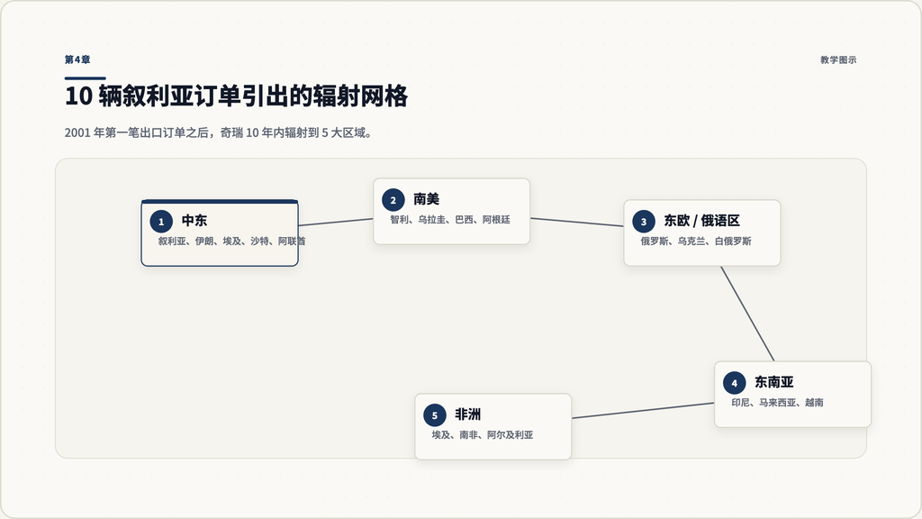

第4章：早期出口的辐射状扩散

### 4.1 出海起点：北京车展上的一次偶遇

2001 年下半年，一位叙利亚的车商在北京一个小型车展上看到了奇瑞刚推出不久的风云。这位车商对这款”在中东少见的中国 B 级轿车”感兴趣，于是从北京一路追到芜湖，再追到上海，最终说服时任奇瑞副总经理的尹同跃，谈下了 10 辆风云的出口订单。

这 10 辆车，是奇瑞——也是中国乘用车——海外出口的真正起点。

如果你只记住一组数字，请记住这两个：**2001 年 10 辆，2024 年 1,144,588 辆**。中间这 23 年，是中国制造业最完整的全球化教科书之一。

### 4.2 为什么是叙利亚，而不是别的市场？

学习者经常会困惑：奇瑞当时一辆车在国内都还没站稳，怎么有底气去出海？真实的逻辑反过来：

- **合资品牌不愿意去的地方，奇瑞才有机会进入**。当时的叙利亚、伊朗、伊拉克、乌兹别克斯坦、苏丹这些市场，欧洲日韩品牌出于合规、安全、政治等理由都不积极。
- **价格敏感市场更接受”质量够用 + 价格便宜一半”的中国车**。这跟奇瑞在国内打的策略是同一条逻辑。
- **小订单容易消化**。10 辆、20 辆的订单对一家百万级别的合资工厂没有意义，但对奇瑞这种刚学会造车的工厂是完美的”练兵”规模。

这三条加在一起，构成了奇瑞早期出海的真正密码：**用边缘市场吃合资品牌看不上的订单，用这些订单养出全球化能力**。

### 4.3 早期 10 个市场：一张辐射状网格

到 2010 年前后，奇瑞主要海外市场已经扩散到一张完整的辐射状网格：

- **中东**：叙利亚、伊朗、埃及、沙特、阿联酋。
- **南美**：智利、乌拉圭、巴西、阿根廷。
- **东欧/俄语区**：俄罗斯、乌克兰、白俄罗斯。
- **东南亚**：印尼、马来西亚、越南。
- **非洲**：埃及、南非、阿尔及利亚。

这些市场的共同特征是：“不受欧美车企重点关注、价格敏感、对中国制造接受度高”。奇瑞用了将近 10 年时间在这些市场里建立经销商网络，每一站都从”10 辆车的整车出口”开始，逐步升级到”几百辆的 CKD（散件组装）“。

### 4.4 早期出口的真实代价：质量事故与召回

如果只讲故事感，奇瑞早期出口可以被写得很浪漫。但实际上代价不小：

- 早期出口车批次质量参差，部分新兴市场在 2005-2008 年间出现过较多投诉与召回。
- 经销商管理体系不成熟，导致售后体验差，反过来拖累品牌口碑。
- 关税与汇率波动一旦出现，整车出口模式利润极薄。

奇瑞从这些事故里得到的最大教训是：**纯整车出口（CBU）模式没有未来，必须走向本地组装和本地化生产**。这个判断后来直接催生了第 8 章会讲到的”海外生产网格化”。

### 4.5 这一章的关键认知

- 出海不是”国内成功的副产品”，它本身就是一条独立战线。
- 边缘市场不是”二等市场”，而是早期出海最好的练兵场。
- 整车出口只是出海的 1.0 版本，不是终点。

### 4.6 用边缘市场打分自己关注的出海公司

请挑出一家你熟悉的中国出海公司（不一定是车企），尝试回答：

- 它的第一个海外订单/客户是哪里？是不是边缘市场？
- 它现在还在那个市场吗？这个市场对它后来的全球化路径有多重要？
- 如果它跳过了”边缘市场练兵”这个阶段，它的国际化能力会发生什么差别？

## 第5章 合资换牌照：奇瑞 × Jaguar Land Rover（2010-2018）

[figure not shown]

第5章：合资换技术与品牌的三步流

### 5.1 自主品牌为什么也要做合资？

中国汽车行业的合资模式通常被理解成”外资带技术、中资出市场”，比如一汽-大众、上汽通用。但 2010 年以后，一些自主品牌也开始反向参与合资，奇瑞是其中最有代表性的一家。

合资对当时的奇瑞至少解决三个问题：

- **第一，**学习高端品牌的整车制造工艺。自主品牌在 30 万元以上的车型上几乎没有制造经验，合资是最快路径。
- **第二，**借助合资品牌的工厂规模摊薄基础设施投入。
- **第三，**为后续自有高端品牌（后来的 EXEED）培养完整的工程团队。

### 5.2 谈判与落地：2010-2014

奇瑞与 Jaguar Land Rover（JLR）的合资项目，关键节点如下：

- **2010 年 8 月**：双方首次披露合作意向。
- **2012 年 3 月**：宣布初始投资 27.8 亿美元，建立 50:50 合资公司——奇瑞捷豹路虎汽车有限公司。
- **2012 年 11 月**：国家发改委正式批准合资。
- **2014 年 10 月 21 日**：常熟工厂正式投产，规划年产能 20 万辆。

常熟工厂之所以重要，是因为它是**Jaguar Land Rover 在英国本土之外的第一座全资历整车工厂**，也是 JLR 全球的”旗舰工厂”。这个身份意味着：

- 工艺标准必须达到 JLR 全球水准。
- 中方工程团队会被深度卷入英国式的产品开发流程。
- 后续 EXEED 品牌的核心制造与工程人员，相当一部分来自这个合资项目。

### 5.3 合资带来的”学习曲线红利”

很多人把奇瑞捷豹路虎合资单纯看作”赚钱业务”，这是低估它的。它真正给奇瑞带来的是三层学习曲线：

- **工程层**：从 NVH（噪声振动）调校到底盘标定，奇瑞工程团队第一次系统接触到 30 万元级以上车型的开发标准。
- **管理层**：JLR 的项目管理、供应商管理、品控管理逻辑被部分移植回奇瑞主品牌。
- **品牌层**：奇瑞第一次近距离观察到一家国际豪华品牌是怎么处理”残值-定价-渠道”的协同。

这三层学习曲线后来被直接复用到 EXEED 品牌，以及 Omoda、Jaecoo 这两个出海副品牌。

### 5.4 合资也带来了限制

合资不是免费午餐：

- 双方各持 50%，所有重大决策都需要协商，速度慢。
- JLR 在新能源转型的迟缓，让合资公司在 2018-2022 年明显被国内新能源品牌甩开。
- 合资工厂的产能利用率随着 JLR 在中国销量下滑而下降，对奇瑞集团整体效率形成拖累。

到了 2020 年代中后期，合资项目在奇瑞集团里的相对重要性在下降，但**它作为”学习窗口”的历史价值已经被完整释放**。这正是合资项目对中国自主品牌最大的意义：它是一个有期限的学习装置，不是一条永远的现金流。

### 5.5 这一章你要带走的判断

- 合资换技术不是只属于”早期合资品牌”的故事，自主品牌后来也用过同一招。
- 合资真正的价值是**学习曲线**，不是利润。
- 合资有”使用周期”：用 8-10 年完成学习，之后必须把学到的能力转移到自主品牌身上。

### 5.6 行动锚点

请尝试回答：

- 如果你是 2018 年的奇瑞高层，你会建议怎么调整与 JLR 的合资关系？为什么？
- 在你熟悉的另一个行业里（手机、家电、生物医药），有没有类似”合资学习窗口”的案例？这家公司退出合资学习窗口之后，做了什么动作？

## 第6章 品牌矩阵的诞生：Chery / EXEED / Omoda / Jaecoo / iCar / Fulwin

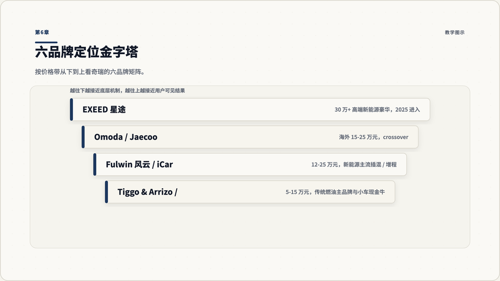

第6章：六品牌定位金字塔

### 6.1 为什么不能只用一个品牌

第 3 章埋下的”奇瑞 = 便宜小车”的低端印象，到了 2015 年前后变成了严重的战略困境。一旦奇瑞想用主品牌做 20 万元以上的车，消费者会立刻打折扣；一旦它想做新能源高端，国内消费者干脆不在认知里给它留位置。

唯一的解法是**重新切分品牌**：

- 不同品牌打不同价格带、不同人群、不同地区。
- 主品牌负责守住基本盘（10-15 万元的家用 SUV 和轿车）。
- 副品牌承担高端化、电动化、海外化的不同任务。

### 6.2 EXEED 星途：高端突围（2017 起）

EXEED 在中文里叫”星途”。它在 2017 年 9 月 14 日的法兰克福车展上以 TX 概念车形式首次亮相。这个发布地点选择很有意思：第一次在德国，而不是在国内某个大型车展。原因有两层：

- 第一，向高端市场宣告”我不是国内便宜车的延伸”。
- 第二，向自己内部明确：“这是面向全球的高端品牌，不是单纯国内产品线”。

2019 年 3 月，EXEED 首款量产车 TX/TXL 中型 SUV 上市。后续主要车型包括 LX、揽月（Lanyue）、凌云（Lingyun）、瑶光（Yaoguang）、星纪元 ES/ET 系列等。

2025 年 12 月 22 日，EXEED 启动所谓”3.0 时代”品牌升级，并一次性发布 ES7 GT、ES8、ET8、ET9 四款车型，全面转向智能新能源豪华定位。

### 6.3 Omoda 与 Jaecoo：海外优先的双品牌（2022-2024）

Omoda 与 Jaecoo 是奇瑞 2022 年之后推出的两个**默认在海外卖**的品牌，国内市场反而是次要场景。这种做法在中国汽车产业里非常少见：通常品牌的母市场都是中国本土，但奇瑞反过来。

两个品牌的分工是这样的：

- **Omoda**：定位”全球领先的 crossover 品牌”，主打城市跨界 SUV，目标是年轻、城市、设计敏感的全球消费者。代表车型：Omoda 5、Omoda 7、Omoda 9，以及 2026 年 4 月正式下线的 Omoda 4。
- **Jaecoo**：定位”全球轻奢越野品牌”，主打有越野能力但又不极端的中型 SUV。代表车型：Jaecoo 7，2025 年开始陆续进入英国、欧洲、东南亚等市场。

到 2025 年，Omoda 与 Jaecoo 合计已进入 64 个市场。2025 年 8 月，两个品牌进入市场 27 个月时累计销量突破 60 万辆。2026 年初，公司宣布从”三年累计百万”切换到”单年百万”的新目标。

### 6.4 iCar：电动小型 SUV 的副品牌（2023 起）

iCar 在 2023 年 4 月作为奇瑞的电动子品牌成立，定位”年轻人的第一辆电动越野”。它的标志性产品是 iCar 03（一辆方盒子造型的纯电小 SUV），主打 12-18 万元价格带。iCar 在国内市场起步阶段就拿到了不错的关注度，2024-2025 年逐步推出 iCar V23、V27 等车型。

iCar 的真正价值不是销量，而是”风格表达”：让奇瑞集团第一次在年轻人心智里有”潮、酷、设计有立场”的位置。

### 6.5 Fulwin 风云：插混与增程的新能源主线（2023 起）

奇瑞把”风云（Fulwin）“这个老名字拿回来用，是 2023 年的一个有意思的动作。新的 Fulwin 系列定位是新能源（插混 PHEV 与增程 EREV）主流家用车，价格带 12-25 万元。代表车型：

- **Fulwin A8、A9**：插混轿车。
- **Fulwin X3 / X3L**：插混与增程 SUV，2025 年起以 12,500-22,000 美元（约 12-16 万元人民币）的价格进入主流家用市场。

Fulwin 是奇瑞主品牌”新能源化”的主战场。2024 年 Fulwin 系列被设定为 20 万辆销售目标。

### 6.6 2025 年的国内重组：四大事业部

2025 年 7 月，奇瑞做了一次国内品牌结构的明确重组，把中国市场分为四个事业部：

- **EXEED 事业部**：高端新能源豪华。
- **Tiggo & Arrizo 事业部**：传统燃油主品牌的家用 SUV 与轿车。
- **Fulwin 事业部**：插混与增程的主流新能源。
- **QQ 事业部**：小车与潮流入门款。

这次重组在管理意义上等同于一句话：**奇瑞终于承认”一个品牌一种打法”在 2025 年已经不够用了**。

### 6.7 把六品牌画成一座金字塔

如果按价格带从下往上画，奇瑞的六品牌矩阵看起来是这样的：

```
            EXEED   ← 30 万元 +，高端新能源
        Jaecoo / Omoda ← 海外 15-25 万元，跨界 + 越野
      Fulwin / iCar    ← 12-25 万元，新能源主流
       Tiggo & Arrizo / QQ ← 5-15 万元，传统主流
```

每一层都对应一个明确的”敌人”：

- EXEED 的敌人是 BBA（奔驰、宝马、奥迪）和理想、蔚来。
- Omoda 与 Jaecoo 的敌人是大众、丰田、现代在海外的入门 SUV。
- Fulwin 的敌人是比亚迪宋 Pro DM-i、深蓝、零跑。
- Tiggo / Arrizo / QQ 的敌人是同价位的合资入门款和其他中国自主品牌。

### 6.8 学习者最容易忽视的细节

- 副品牌不是”花架子营销动作”，是真正用来切割消费者心智的工具。
- 奇瑞用副品牌做了一件中国汽车产业里不常见的事：**海外副品牌优先于国内副品牌**（Omoda、Jaecoo 都是先打海外）。
- 同一家公司同时养六个品牌不是越多越好，反而要求极强的资源调度纪律。

### 6.9 给一个非汽车行业画一张品牌金字塔

挑一个国内消费品行业（白酒、家电、化妆品都行），画一张类似的六品牌金字塔：

- 这家公司在每一层放了谁？
- 哪一层是它的现金牛，哪一层是它的未来叙事？
- 它在海外市场用的是国内品牌名，还是另一个名字？为什么？

## 第7章 海外扩张的三种打法：俄罗斯、巴西、欧洲

[figure not shown]

第7章：三市场打法对照

### 7.1 同一家公司，三种完全不同的逻辑

最容易让出海学习者犯错的判断是：“一家公司在海外用的就是一套打法”。在奇瑞身上，这个判断完全错误。它在三个最重要的市场——俄罗斯、巴西、欧洲——用了三种几乎相反的逻辑。

### 7.2 俄罗斯：填补西方退出后的真空（2022-2025）

2022 年开始，西方汽车品牌大规模退出俄罗斯市场。这一动作给奇瑞留出了一个超级真空：

- 2024 年俄罗斯销售约 318,000 辆奇瑞车，约占俄罗斯整体新车销量的 1/5。
- 2024 年俄罗斯市场贡献了奇瑞集团总收入的约 25.5%。
- 奇瑞甚至超过本地品牌 Lada，成为俄罗斯第二大乘用车品牌。

但这场看起来辉煌的胜利埋着一个巨大的合规雷：奇瑞作为一家计划在港股 IPO（融资约 12 亿美元）的中国公司，如果继续大规模在俄罗斯销售，会触发西方对其的二级制裁风险。结果是 2025 年 9 月，奇瑞宣布**逐步退出俄罗斯市场**，计划到 2027 年完成全面退出。

俄罗斯故事里的真正教训是：

- 出海可以靠”地缘真空”短期爆发。
- 但靠地缘真空赚到的钱有一个隐形天花板：上市与全球合规。
- 真空市场要被当作”过渡资本”，而不是”长期资产”。

### 7.3 巴西：把自己变成本地公司（2014 起）

奇瑞在巴西的路径完全不同。它**2014 年就在巴西雅卡雷伊（Jacareí）建了一座整车工厂**，并陆续在巴西完成了第二座工厂的建设。到 2025 年：

- 巴西全年销量约 14.39 万辆。
- 零部件本土化率超过 65%。
- 奇瑞已经被巴西消费者认知为”在本地造车的品牌”，而不是”进口车”。

巴西故事最重要的一点是：奇瑞用 10 年时间把自己从”出口商”变成了”本地公司”，这意味着汇率风险、关税风险、政治风险都被显著对冲。

### 7.4 欧洲：用合资 + 老品牌进入（2024 起）

欧洲市场对中国车企的难度是天花板级别：

- 安全法规、环保法规、L 类认证都比新兴市场严苛得多。
- 欧盟在 2024 年开始对中国电动车征收新的反补贴关税。
- 消费者对中国品牌的认知度低、信任成本高。

奇瑞的应对方式是**和西班牙 Ebro-EV Motors 合资**，用一座前 Nissan 工厂作为生产基地：

- 2024 年 4 月签约成立合资公司。
- 2024 年 11 月 23 日，第一辆挂 Ebro 标的 S700 SUV 在巴塞罗那 Zona Franca 工厂下线。
- 规划目标：2027 年产能达到 50,000 辆，2029 年达到 150,000 辆，提供约 1,250 个本地就业岗位。
- 同时 Omoda、Jaecoo 通过英国、西班牙、意大利、德国等市场进入欧洲，2024 年起 Omoda & Jaecoo 在欧洲已覆盖 9 个市场。

欧洲故事最有意思的点是奇瑞**把自己藏在 Ebro 这个西班牙老品牌后面**——Ebro 是 20 世纪西班牙的商用车品牌，奇瑞把它复活，借用它在西班牙消费者心目中的本土感来降低进入门槛。这是一种”反向品牌借壳”。

### 7.5 三种打法的对照

把三种打法放在一张表里，会清楚地看到逻辑差异：

| 市场 | 进入方式 | 主要风险 | 应对手段 |
| --- | --- | --- | --- |
| 俄罗斯 | 整车出口 + 经销商网络 + 西方退出真空 | 二级制裁、合规风险 | 主动退出、转移产能 |
| 巴西 | 本地建厂 + 本地化零部件 + 长期经销 | 汇率、政治周期 | 深度本地化 |
| 欧洲 | 与本地合资 + 复活当地老品牌 | 高门槛、品牌信任 | 借壳 + 多副品牌并行 |

学习者从这张表里要带走的不是”哪种打法最好”，而是”**不同市场必须用不同打法**”。奇瑞的真正能力是**在三个市场里同时维护三种打法的纪律**，不混淆、不复制粘贴。

### 7.6 这一章的关键检查点

- 不要把”出口冠军”误读成”用同一招打遍所有市场”。
- 出海的真正难点是**风险结构的差异**：地缘真空、汇率、合规、关税、品牌信任不会用同一个解法。
- 把每一个海外市场都看作一个独立的子公司战略问题，而不是销售延伸。

### 7.7 用三种打法纪律重做一次海外战略

请挑一家你熟悉的出海公司，做以下两题：

- 它在欧洲、东南亚、中东这三个市场里，是不是用同一套渠道与品牌？这是它的优势，还是隐形负债？
- 如果它要用奇瑞的”三种打法纪律”重做一次海外战略，它最该改的是哪个市场？

## 第8章 海外生产网格：10+ 本地工厂的战略意义

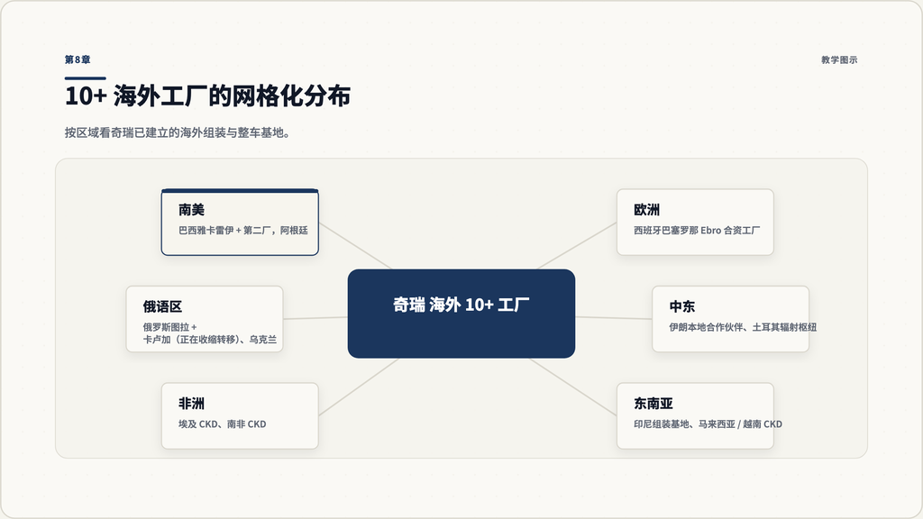

第8章：奇瑞海外生产网格示意

### 8.1 出口的天花板：纯整车贸易撑不到天花板

第 4 章末尾埋了一个判断：纯整车出口（CBU）模式没有未来。这一章把这个判断展开。

整车出口的问题在四个层面：

- **关税**：很多市场对整车进口征 30%-100% 的关税，本地组装可以大幅下降到几个百分点。
- **汇率**：人民币-当地货币的波动会直接吃掉利润，本地化采购可以对冲。
- **物流**：海运成本和时间不可控，一次红海危机就能毁掉一个季度。
- **政治**：本地化生产几乎是任何国家政府”友好对待外资”的前提条件。

### 8.2 奇瑞的海外工厂分布

到 2026 年初，奇瑞在海外建立了 10 个以上的生产基地，覆盖：

- **俄罗斯**：图拉工厂、卡卢加附近的 CKD 装配厂（注：随退俄战略，这部分产能正在转移）。
- **乌克兰**：早期 CKD 工厂（受 2022 年战争影响，现状有限）。
- **土耳其**：与本地伙伴合作的组装基地，主要面向中东与东欧。
- **伊朗**：长期合作的本地组装伙伴，是奇瑞在中东的传统强势市场。
- **埃及**：本地 CKD 厂，辐射北非。
- **南非**：CKD + 经销渠道，目前是中国车在南非市占最高的品牌之一。
- **印度尼西亚**：东南亚最重要的本地组装基地。
- **马来西亚 / 越南**：通过本地合作伙伴完成 CKD。
- **阿根廷**：南美早期本地化布局。
- **巴西**：两座整车工厂（详见第 7 章）。
- **西班牙巴塞罗那**：与 Ebro-EV Motors 合资工厂（详见第 7 章）。

这些工厂呈现出一个明显的”网格化”特征：每一个区域都有 1-2 个本地节点，节点之间形成补充而不是冗余。

### 8.3 海外工厂的三层角色

不要把这些工厂当成同质化资产。它们在战略上至少承担三层角色：

- **第一层：关税与本地化合规节点**。最典型的例子是巴西、印尼、土耳其，主要任务是把整车的”中国制造”标签转换成”本地制造”。
- **第二层：地区辐射枢纽**。比如埃及辐射北非、土耳其辐射中东与东欧、印尼辐射东南亚。这一层的关键是物流半径与海关协定。
- **第三层：技术与品牌升级节点**。最典型的是西班牙巴塞罗那的 Ebro 合资工厂——它的真实任务不是”造车赚钱”，而是让奇瑞拿到一个能进入欧盟、进入”欧洲制造”叙事的入口。

理解这三层之后，你会发现奇瑞的海外工厂不是简单的”产能扩张”，而是**一张被精心设计的全球网格**。

### 8.4 海外工厂的隐藏代价

不能只讲优势。奇瑞海外工厂网络也带来三类隐藏代价：

- **资本占用**：每一座海外工厂需要 1-5 亿美元级别的初始投入，长期 ROI 不能保证。
- **管理半径**：本地工人、本地法规、本地工会需要本地化管理团队，跨文化失败是中国出海公司最常见的死法之一。
- **合规暴露**：工厂数量越多，公司在各种制裁、贸易调查中的暴露面就越大。退俄战略本质上就是为了清理这种暴露面。

### 8.5 这一章你要带走的判断

- 海外销量超过 100 万辆之后，**单靠整车出口几乎不可能维持**。
- 本地工厂是出海公司的”成年仪式”，不是奖励，而是入场券。
- 工厂网格化要回答的不是”建几个工厂”，而是”每个工厂在战略上扮演什么角色”。

### 8.6 行动锚点

如果你管理的是一家年出口 5 万-50 万辆/件的中国出海公司，请回答：

- 你的第一个海外工厂应该建在哪？理由是关税、辐射、还是技术升级？
- 你目前已有的海外工厂里，有没有一座其实在战略上没有角色？

## 第9章 2024-2026 的转折点：百万出口、退俄、港股 IPO

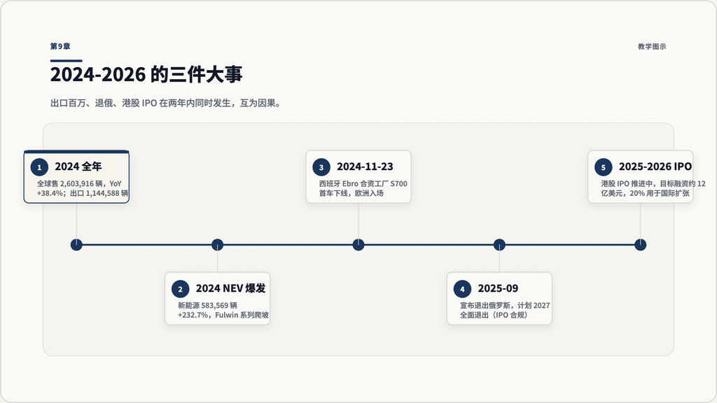

第9章：三件大事互相塑造

### 9.1 三件事同时发生

2024-2026 年是奇瑞历史上最不平静的两年。三件互相牵动的大事同时发生：

- **2024 全年**：全球销量 2,603,916 辆（YoY +38.4%），出口 1,144,588 辆（YoY +21.4%），新能源销量 583,569 辆（YoY +232.7%）。
- **2025-09**：宣布退出俄罗斯市场，计划 2027 年完成全面退出，原因是为港股 IPO 合规。
- **2025-2026**：港股 IPO 推进中，目标融资约 12 亿美元，其中约 20% 资金用于国际扩张。

这三件事不是孤立的，它们互为因果。

### 9.2 出口百万是 IPO 的故事，也是 IPO 的代价

资本市场喜欢”全球化叙事”。奇瑞在 2024 年达到出口 114 万辆+，是它能在港股拿到合理估值的关键卖点。但同时，资本市场也要求”合规叙事”。

如果奇瑞继续大量在俄罗斯销售，会出现两个问题：

- 西方投资银行不愿意参与它的 IPO。事实上，摩根大通已经在 2025 年退出奇瑞 IPO 项目，原因正是俄罗斯业务。
- 上市后，每一次西方制裁动作都可能直接影响股价。

所以**“退俄”是 IPO 的入场费**。奇瑞失去的是俄罗斯短期收入（2024 年占总收入约 25.5%），换回的是港股估值与未来 5-10 年的资本通路。

### 9.3 新能源 + 海外 = 双线叙事

奇瑞为了 IPO 准备的两条增长线很清晰：

- **新能源线**：Fulwin 系列、EXEED 3.0 时代电动车（ES7 GT / ES8 / ET8 / ET9）、iCar V27 等增程车型，2024-2026 是密集上量期。
- **海外线**：Omoda & Jaecoo 从”三年累计百万”切换到”单年百万”目标，2027 年要覆盖 108 个国家。

这两条线绑在一起讲，就是一句话：**奇瑞从”中国便宜车出口商”重新定位为”全球新能源汽车制造商”**。

这是一个心智的根本切换，也是估值故事的核心。

### 9.4 这个转折点的三种结局

未来 3-5 年，奇瑞可能走向三种结局：

- **结局 A：港股上市成功，估值高位**。新能源、欧洲、东南亚、巴西齐头并进，俄罗斯收入被替换。
- **结局 B：港股上市，但估值平庸**。海外百万目标受关税、合规、地缘影响达不到，新能源利润率被比亚迪、吉利碾压。
- **结局 C：IPO 推迟或失败**。地缘恶化、关税升级、合规问题集中爆发。

不论是哪种结局，奇瑞过去 25 年积累的”全球网格 + 多品牌矩阵”都不会消失。它的真正护城河不是 IPO，而是”在 110 个国家活着的能力”。

### 9.5 这一章你要带走的判断

- 出海公司到了一定体量后，**资本市场会反过来塑造战略**：上市目标会决定你今天去哪个市场、退出哪个市场。
- 短期收入和长期资本通路经常是冲突的。退俄就是这种冲突最赤裸的体现。
- 全球化叙事 + 新能源叙事 + 资本叙事，这三个叙事必须互相支撑，不能互相打架。

### 9.6 行动锚点

请挑一家你认为接下来 3 年会推动上市的中国出海公司，回答：

- 它今天的哪个市场是”短期收入但长期合规风险”的来源？
- 如果它必须为上市做一次”退俄式”动作，它会从哪个市场退？为什么？

## 第10章 奇瑞经验对中国出海的可迁移启示

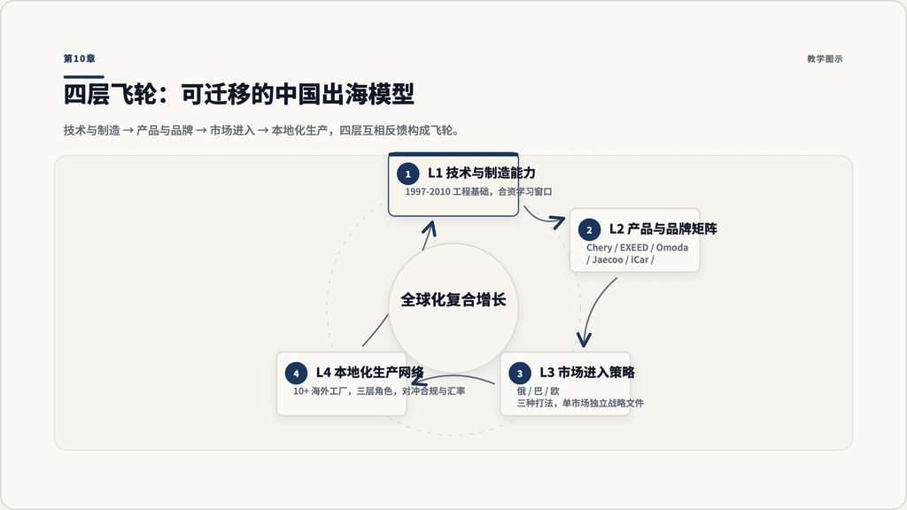

第10章：四层飞轮模型

### 10.1 把奇瑞 25 年抽象成一个模型

最后一章，我们要做的事是把前面 9 章的所有具体故事，压缩成一个可以应用到其他出海公司的可迁移模型。

我把它叫做”四层飞轮”：

- **第一层：技术与制造能力**。这是奇瑞 1997-2010 年最痛苦的功课，没有任何捷径。
- **第二层：产品与品牌矩阵**。能在不同价格带、不同人群、不同地区用不同品牌打不同的战。
- **第三层：市场进入策略**。每个海外市场要用单独的逻辑，不能”复制粘贴中国成功”。
- **第四层：本地化生产网络**。当某个市场进入第二阶段时，必须从出口走向本地建厂。

这四层不是阶梯，而是同时旋转的飞轮：

- 第一层为第二层提供工程基础。
- 第二层为第三层提供产品弹药。
- 第三层为第四层提供本地市场的”建厂资格”。
- 第四层反过来给第一层提供本地工程反馈，让技术能力进一步进化。

只有当这四层互相反馈时，公司才进入真正的”全球化复合增长”阶段。奇瑞在 2018 年之前主要在第一、第二层挣扎，2018-2024 年完成了第三层飞轮的搭建，2024 年之后正在加速第四层。

### 10.2 把四层飞轮变成 checklist

如果你现在管理一家正在出海的中国制造业公司，这四层可以被拆解成一份具体的自检 checklist：

**第一层：技术与制造能力**

- 你的产品在没有合资伙伴帮助的情况下，能不能稳定量产 5 年？
- 你的工程团队有没有”看过更高一级标准的工厂”的经验？
- 你有没有一座可以做学习窗口的合资 / 合作项目？

**第二层：产品与品牌矩阵**

- 你的国内主品牌有没有”低端心智固化”风险？
- 如果有，你的副品牌是否独立运营、独立营销、独立招聘？
- 你的副品牌是否敢于”海外优先”，而不是”国内试错后才出海”？

**第三层：市场进入策略**

- 你在每一个海外市场是否有独立战略文件，而不是”用同一份 PPT 改国家名字”？
- 你是否区分了”地缘真空型市场”、“长期消费型市场”、“高门槛型市场”？
- 你的退出机制是否被提前设计（特别是合规风险高的市场）？

**第四层：本地化生产网络**

- 你目前的海外销量结构里，整车出口占多少？本地组装占多少？
- 你是否有清晰的”建厂判断三问”：关税收益、辐射半径、技术/品牌升级？
- 你有没有一座”为下一代品牌叙事服务”的旗舰工厂？

### 10.3 奇瑞经验不能 100% 复制的部分

诚实地说，奇瑞模式有一部分是不可复制的：

- 它的体制基因（地方国资 + 工程师团队）很难在一家纯民企身上重建。
- 它的”先难市场练手”路径吃了 1990-2010 年的地缘红利，今天的新兴市场难度更高。
- 它和 JLR 的合资学习窗口处于 2012-2020 年这个特殊窗口期，今天再去找一个对等的国际合作伙伴会非常难。

但**四层飞轮的结构本身可以被任何制造业公司复用**。不一定每一家都能跑通，但凡是想做真正”全球化”而不是”国际化”的公司，都绕不开这四层。

### 10.4 把这门课收尾

奇瑞 1997-2026 这 29 年，本质上是一家中国制造业公司从”地方小厂”走向”全球网格”的完整样本：

- 它没有冠军车型。
- 它在国内不被消费者偏爱。
- 它经历过设计争议、品控塌陷、品牌固化、地缘风暴。
- 但它在 110 个国家里都活着，并且把出口冠军的位置坐了 22 年。

把这件事看清楚，对所有想出海的中国公司都是一面镜子：**全球化不一定靠国内冠军身份**，但一定靠**多层结构的飞轮**。

### 10.5 最后的练习

请用 500-800 字写一份给自己的”四层飞轮自检报告”：

- 你或者你正在跟踪的公司，今天在哪一层最强？
- 哪一层最弱？
- 你下个季度可以做一件什么样的小事，让最弱的那一层往前转半圈？

写完之后保存好，6 个月后再回来看一次。

## 第11章 横向对比：奇瑞 vs 比亚迪 vs 长城 vs 上汽

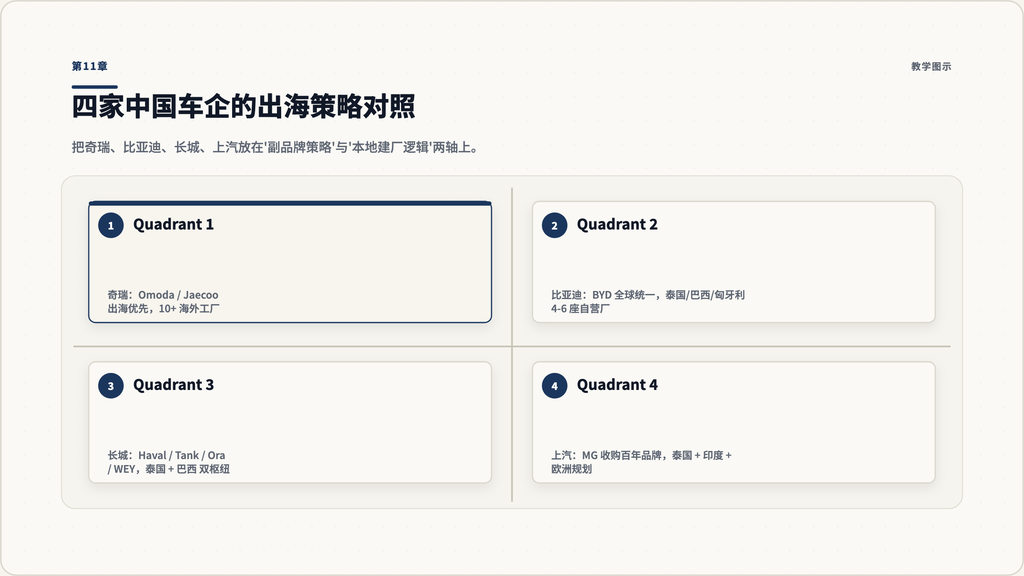

第11章：四家中国车企的出海策略对照

### 11.1 为什么要做这场对比

把奇瑞单独看会得出一个结论：它是中国出海最成功的车企。把它和比亚迪、长城、上汽放一起，结论会立刻改写：**它是路径最独特的那一家**，不是唯一成功的那一家。

学习者最容易犯的错误是”把奇瑞模式当成中国出海的标准答案”。真实情况是，今天中国主要车企的海外策略已经分化成至少四种不同的逻辑，每一种背后都对应一种不同的资源禀赋、不同的市场定位、不同的资本叙事。

这一章把四家公司在四个维度上的策略并排放出来。

### 11.2 四公司四维度

四个维度分别是：

- **维度 1 — 出海规模与节奏**：从什么时候开始、多大体量、增长曲线长什么样。
- **维度 2 — 副品牌策略**：海外用主品牌还是副品牌，副品牌是为海外造的还是国内副品牌的延伸。
- **维度 3 — 本地建厂逻辑**：先出口还是先建厂；建厂集中在哪几个区域；和谁合资。
- **维度 4 — 新能源 vs 燃油的权重**：海外卖的车以新能源为主还是以燃油为主。

### 11.3 奇瑞：先难市场、多副品牌、网格化建厂

- **规模**：2024 出口 1,144,588 辆，连续 22 年第一；累计破 500 万辆。
- **副品牌**：海外副品牌优先（Omoda、Jaecoo 默认海外；EXEED 国内+海外同步；iCar、Fulwin 主要在国内）。
- **本地建厂**：10+ 海外工厂网格化分布，从中东、南美、东南亚到欧洲都有；2024 进入欧洲用与西班牙 Ebro 合资。
- **新能源比重**：海外仍以燃油 + 插混 SUV 为主；新能源比例正在快速上升。

### 11.4 比亚迪：电动一张牌、全球品牌统一、自营工厂

- **规模**：2024 出口约 41.7 万辆；2025 前 11 个月海外销量已破 90 万辆，全年有望破百万。目标 2030 年海外销量占总销量 50%。
- **副品牌**：主品牌 BYD 全球统一使用；高端 Denza（腾势）、Yangwang（仰望）准备进入欧洲，对标沃尔沃到法拉利的价格带；越野副品牌 Fang Cheng Bao（方程豹）国内为主。
- **本地建厂**：泰国罗勇 2024-07 投产 15 万辆产能（比亚迪首座海外全资工厂）；乌兹别克斯坦组装；巴西 Camaçari、匈牙利 Szeged、土耳其 Manisa 在 2025-2026 陆续投产，单厂目标 15 万辆/年。
- **新能源比重**：基本 100% 新能源（纯电 + 插混），不卖燃油。

### 11.5 长城（GWM）：多品牌组合、东南亚 + 拉美双枢纽

- **规模**：2024 全年集团销量约 123 万辆；2024 前 9 个月海外销量 32.4 万辆，YoY +53.16%；2024-12 单月海外销量 41,293 辆，YoY +23.35%。
- **副品牌**：海外组合最完整——Haval（哈弗，SUV 主力）、Tank（坦克，硬派越野）、Ora（欧拉，纯电小车）、WEY（魏牌，新能源轻奢）、长城商用（皮卡）。每个品牌承担不同价格段。
- **本地建厂**：泰国 Rayong 是其海外首座新能源整车厂；巴西 Iracemápolis 工厂规划为”全球智能生产基地”，预计 2025 年中投产；同时在俄罗斯、巴基斯坦也有 KD 装配厂。
- **新能源比重**：海外以燃油 SUV / 皮卡 + 部分新能源（Ora / WEY 试水），整体新能源比重低于比亚迪、奇瑞 Fulwin。

### 11.6 上汽（SAIC / MG）：百年老牌当壳、欧洲 + 东南亚 + 印度三线

- **规模**：上汽是中国整车厂出口榜上的第二位（仅次于奇瑞）；其中 MG 是核心海外品牌，年销量百万级别。
- **副品牌**：**最特别的一家——直接收购了英国百年品牌 MG（2007 年收购）作为全球品牌**。这等于”出生就有海外资产”。商用车线用 Maxus（大通）；新能源高端用 IM Motors（智己）的全球版本，部分车型甚至直接把 R7、F7 改名 MG9 EV、MG S9 EV 进入海外。
- **本地建厂**：2017 年开建泰国春武里工厂（10 万辆/年）；印度 2017 接手通用 Halol 工厂，2023 年 5 月起因印度政府压力被迫减持，与 JSW 集团组成合资公司（JSW 持 35%）；欧洲工厂选址 2024-2025 年决策中，西班牙加利西亚领先，首期目标 10 万辆/年。
- **新能源比重**：海外 MG4 是欧洲明星纯电产品；整体海外销量里电动比例显著高于长城、奇瑞。

### 11.7 一张表把四家放在一起

| 维度 | 奇瑞 | 比亚迪 | 长城 | 上汽 |
| --- | --- | --- | --- | --- |
| 起点 | 2001 叙利亚 10 辆风云 | 2010 年代开始全球 EV 试水 | 2010 年代俄、中东、东南亚 | 2007 收购 MG 后直接全球化 |
| 2024 出口 | 114 万辆 +21.4% | 41.7 万辆 | 海外 32 万+（前 9 月） | MG 海外百万级 |
| 主要海外品牌 | Omoda / Jaecoo / EXEED | BYD（统一） | Haval / Tank / Ora / WEY | MG / Maxus / IM |
| 副品牌逻辑 | 海外优先创造副品牌 | 不分国内国外，主品牌统一 | 多品牌组合，分价格段 | 收购老品牌做”反向借壳” |
| 海外工厂数量 | 10+ | 4-6（投产 + 建设中） | 5-7 | 4-6（含印度合资） |
| 旗舰海外工厂 | 西班牙 Ebro 合资 | 泰国 Rayong 自有 | 泰国 Rayong + 巴西 | 泰国 + 西班牙规划中 |
| 新能源比重 | 中（上升中） | 极高（接近 100%） | 中低 | 中高 |
| 资本叙事 | 港股 IPO 2025-2026 | A 股 + 港股已上 | A 股 + 港股已上 | A 股 + H 股已上 |

### 11.8 学习者最容易看错的两件事

**第一**：体量大不等于策略好。奇瑞的”22 年第一”是用时间换的；比亚迪的”5 年破百万出口”是用电动赛道换的。把两者放在同一根尺子上比，会忽略它们背后完全不同的禀赋。

**第二**：副品牌不是越多越好。奇瑞的副品牌矩阵看起来最复杂，但它是被国内”低端心智固化”逼出来的；比亚迪不需要副品牌，因为它本身就是新能源时代的强心智品牌；上汽不需要从零做副品牌，因为它收购了 MG。**别人的副品牌策略不能直接复制——你得先看自己的母品牌强不强**。

### 11.9 把这张对比表反向用一次

请挑出一家你认识的中国出海公司（不局限于汽车），把它放在这张 4x4 的表格里：

- 它在哪一栏最像奇瑞？
- 在哪一栏最像比亚迪、长城、上汽？
- 有没有哪一栏它是独立的第五种？
- 如果它要为下一轮全球化转型借鉴一家，最该借哪家？

写出来。如果一家公司在四个维度上都找不到对照，要么它是一种全新模式，要么它的全球化还没真正开始。

## 第12章 深度案例 A：奇瑞 × Jaguar Land Rover 合资全解

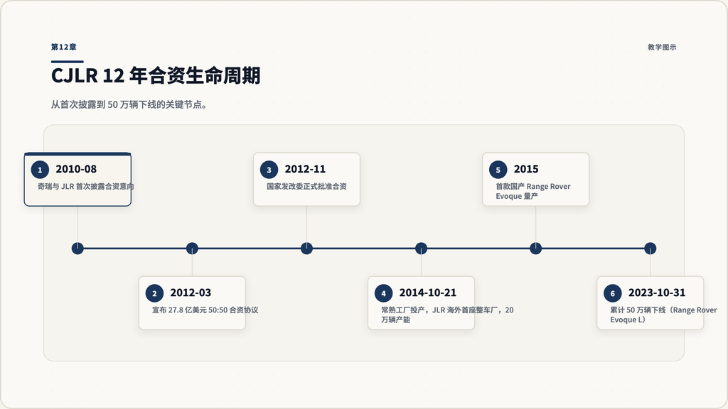

第12章：CJLR 12 年合资生命周期

### 12.1 把第 5 章的”学习窗口”打开

第 5 章已经讲过奇瑞与 Jaguar Land Rover（JLR）合资项目的整体逻辑。这一章把它当作一个**完整的案例**单独拆，目标是让你从中提炼出”自主品牌做合资学习窗口”的可复用框架。

合资项目在中文叙事里经常被脸谱化：要么是”市场换技术”的简单标签，要么是”双 50% 股权所以谁也说了不算”的吐槽。CJLR 是一个能让你看清这两种叙事都太浅的案例。

### 12.2 完整时间线（2010-2026）

- **2010-08**：奇瑞和 JLR 首次披露洽谈合资意向。
- **2012-03**：双方宣布合资协议，初始投资 27.8 亿美元，建立 50:50 合资公司——奇瑞捷豹路虎汽车有限公司（CJLR）。
- **2012-11**：国家发改委正式批准合资。
- **2014-10-21**：常熟工厂正式投产，规划年产能 20 万辆。**这是 Jaguar Land Rover 在英国本土之外的第一座全工艺整车厂**。
- **2015**：首款国产车型路虎极光 Range Rover Evoque 量产，标志合资进入”本地化生产”阶段。
- **2015-2019**：陆续投产路虎发现神行（Discovery Sport / PHEV）、捷豹 XFL、捷豹 XEL、捷豹 E-PACE 等车型；同时建立 R&D 中心，本地化工程能力逐步成型。
- **2023-10-31**：累计第 500,000 辆下线，车型是 Range Rover Evoque L。从投产到累计破 50 万辆用了约 9 年。
- **2024-2026**：JLR 全球电动化进程慢于中国本土品牌；CJLR 在中国市场销量明显承压；合资关系进入战略调整期。

### 12.3 这场合资真正完成的三件事

抛开公关稿叙述，CJLR 对奇瑞最实质的三件事是：

**第一，工程标准的”硬升级”**。在合资之前，奇瑞的整车开发标准是”够用就好”。在合资之后，奇瑞工程团队第一次接触到 JLR 全球流程里关于 NVH（噪声振动）、白车身精度、整车密封性、底盘标定等的硬指标。这部分能力后来直接被复用到 EXEED。

**第二，本地化供应链的”高端层”建立**。要在常熟造 Range Rover Evoque，奇瑞需要在国内组织起一条能满足 JLR 标准的零部件供应链——这条供应链后来成了 EXEED、Omoda、Jaecoo 上游零部件的基础。

**第三，品牌运营的”全周期观察”**。从产品定价、渠道分销、二手车残值管理、品牌广告投放，到经销商培训，奇瑞获得了一个观察 JLR 完整品牌运营动作的窗口。

### 12.4 合资不是免费的

合资的代价同样真实：

- **决策慢**：双方各持 50%，所有重大产品决策都需要协商。在 2018-2022 年中国新能源市场剧变期，CJLR 没能及时电动化，错过了关键窗口。
- **JLR 全球策略拖累**：JLR 自身在 2020 年代面临英国本土产能、电动化转型、Tata 集团战略调整等问题；合资公司被动跟随。
- **机会成本**：奇瑞投入合资的资金与团队，如果完全自己用，能不能做出一个比 EXEED 更高级的自主高端品牌？这是一个永远没法被验证的反事实。

### 12.5 案例提炼的可复用框架

把 CJLR 抽象成”自主品牌做合资学习窗口”的框架：

1. **学习窗口要有起点**：合资协议明确双方分工和投入。
2. **学习窗口要有里程碑**：工厂投产、首款车下线、累计销量节点，是学习曲线的具体表现。
3. **学习窗口要有”反哺触点”**：合资工程师轮岗回主品牌、合资供应链向主品牌开放、合资品牌运营经验向主品牌移植。
4. **学习窗口要有”退出预期”**：合资不是永久现金流，要在 8-10 年内把能力沉淀进自主品牌；超过窗口期，合资从资产变成负担。

**奇瑞的 CJLR 在 1-3 步做得相当完整，第 4 步——退出预期——是它进入 2024-2026 年最棘手的命题**。

### 12.6 把 CJLR 框架映射到你的行业

请挑一个你熟悉的行业（手机、家电、生物医药、半导体），回答：

- 它过去 20 年有没有”学习窗口式”的合资项目？
- 这个学习窗口在哪一年应该退出？现实里退出了吗？
- 没退出的合资项目，今天对母公司是资产还是负担？

如果你正在做的事情和奇瑞 2010 年的处境相似（自主品牌想做高端、但没经验），你能不能找到一个合理的合资学习窗口？

## 第13章 深度案例 B：Omoda & Jaecoo 欧洲渠道扩张

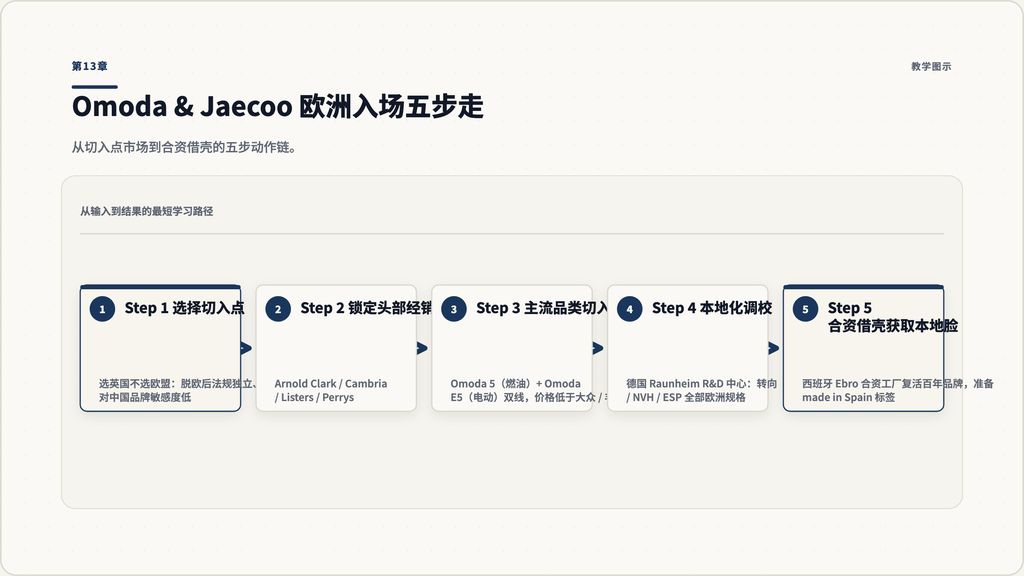

第13章：Omoda & Jaecoo 欧洲入场五步走

### 13.1 为什么单独讲欧洲

欧洲是中国车企最难啃、也最被低估的市场。它的安全法规、环保法规、消费者品牌信任，三个加在一起几乎是所有新兴市场难度的总和。但奇瑞用 Omoda 和 Jaecoo 这两个**专门为海外打造的副品牌**，在 12 个月内完成了欧洲入场，是出海行业 2024-2026 年最值得拆解的案例之一。

这一章拆解的不是车型本身，而是**渠道扩张的”五步走”动作链**。

### 13.2 时间线：12 个月里发生了什么

- **2024-04-21**：奇瑞与西班牙 Ebro-EV Motors 签署合资协议，准备复活百年商用车品牌 Ebro 作为欧洲制造的”皮”。
- **2024-08**：Omoda & Jaecoo 正式在英国上市，首发 Omoda 5 + Omoda E5 两款 crossover SUV。英国首批合作经销商 70+ 家。
- **2024-08 至 2024-12**：5 个月内英国累计上牌 3,838 辆。在英国市场，这是一个外国新品牌的”健康节奏”——不爆量，但站稳。
- **2024-11-23**：西班牙巴塞罗那 Zona Franca 工厂第一辆 Ebro S700 SUV 下线，欧洲制造正式开始（前 Nissan 工厂复用）。
- **2025-Q1**：英国经销商网扩张到 71 家，9 家在建中；产品线增加 Jaecoo 7 SUV，进入更主流的 C 段 SUV 价格带。
- **2025 全年**：英国上牌量从 3,838 辆跳到 48,087 辆，YoY 增长超过 10 倍；经销商网增长到 101 家；单月最高市占达到 2.71%。
- **2026-04**：母公司 OMODA & JAECOO 全球宣布从”三年累计百万”切换到”2027 年单年百万”目标，欧洲被定位为最重要的增长引擎之一。

### 13.3 渠道扩张的五步动作链

把这 12 个月的所有动作拆开，你会看到一个清晰的五步走：

**Step 1：选择切入点市场（英国，不是欧盟）**

- 英国脱欧后已经不在欧盟 CBAM 关税框架里，可以直接出口整车而不被欧盟反补贴关税重击。
- 英国消费者对”中国品牌”的认知度高于德法意（因为已经有 MG、比亚迪在卖）。
- 英国汽车经销集团高度集中（Arnold Clark、Cambria、Listers、Perrys 等掌握大量门店），谈定几家头部就能快速铺开。

**Step 2：拿到头部经销集团做”船票”**

- 与 Arnold Clark、Cambria、Listers、Perrys 等头部零售集团签合作，意味着 Omoda & Jaecoo 一进入英国就能在最好的展厅位置和最强的销售团队下卖车。
- 这一步抹掉了”新品牌没有渠道”的最大冷启动问题。

**Step 3：在英国市场用”主流 SUV + 同价位电动版”做切入**

- Omoda 5（燃油版）+ Omoda E5（电动版）双线，覆盖”想换电动但还没下决心”的过渡用户。
- 价格带卡在大众 Tiguan、丰田 RAV4 同段，但便宜约 20-30%。
- 用熟悉的车型类别 + 熟悉的价格段 + 不熟悉的品牌 → 降低消费者决策门槛。

**Step 4：建立欧洲 R&D 中心做”本地化调校”**

- 在德国法兰克福附近的 Raunheim 设立欧洲研发中心，所有进入欧洲的车型必须经过本地化调校（转向、悬挂、ESP、噪声、NVH）。
- 这一步是”我们不是把中国车原样运过来”的最强证明，对欧洲媒体测评至关重要。

**Step 5：用合资工厂获取”欧洲制造”叙事**

- 通过 Ebro 合资工厂获得”made in Spain”标签，部分车型未来可以在欧洲本地下线。
- 同时为”如果欧盟未来对中国整车进一步加税”准备好规避路径。

### 13.4 这个案例最有教学价值的两个动作

**第一是”先英国后欧盟大陆”的次序**。中国车企通常会先选德国（最大市场）或法国（汽车文化象征）。Omoda & Jaecoo 反过来，先吃英国的好处——脱欧后法规独立、经销渠道集中、消费者对中国品牌敏感度低。**这是一个真实的”市场进入次序”案例，不是凭直觉选大市场，而是按”难度梯度”选切入口**。

**第二是”副品牌出海 + 老品牌借壳”的双轨**。Omoda 和 Jaecoo 是奇瑞为海外造的全新副品牌，没有奇瑞主品牌的低端包袱；Ebro 是西班牙 20 世纪老商用车品牌，奇瑞复活它，借走它在西班牙消费者心中的本土感。**两套品牌叙事并行：年轻新品牌打消费者认知，老品牌打监管/媒体/政府关系**。

### 13.5 这个模式适用 vs 不适用的场景

适用场景：

- 母品牌在国内有强心智、但海外没认知。
- 目标市场监管或文化门槛高，需要”本地脸”降低进入摩擦。
- 母公司有足够现金可以同时养两套品牌运营团队。

不适用场景：

- 母品牌本身是全球品牌（不需要副品牌，比如比亚迪）。
- 海外市场是新兴市场（消费者不在乎”是不是本地品牌”，更在乎价格）。
- 公司规模太小，没法承担两套独立营销与渠道团队。

### 13.6 把这套五步走映射到你的产品

请挑一个你正在做或计划做的海外项目，按这五步检查一遍：

- 你选择的切入点市场是不是难度梯度最低的那一个？
- 你有没有头部渠道伙伴愿意第一时间接你？
- 你用的产品组合是不是”熟悉品类 + 熟悉价格 + 不熟悉品牌”？
- 你有没有在目标市场做本地化调校？
- 你有没有一个”本地脸”的合资或借壳路径作为长期保险？

如果有 3 步以上是空的，你的欧洲（或其他高门槛市场）入场可能需要重新设计。

## 第14章 深度案例 C：退出俄罗斯的合规博弈

[figure not shown]

第14章：留在俄罗斯 vs 退出的代价对照

### 14.1 这不是一个”道德选择题”

退俄案例最容易被讲成两种简化叙事：要么是”奇瑞终于醒悟、加入西方合规阵营”，要么是”奇瑞被迫放弃最大海外市场、损失惨重”。**两种叙事都太懒**。真实情况是一场冷静的资本博弈：用短期 25% 收入换取长期资本通路。

这一章把这个博弈的所有具体数字、动作、代价拆开放在桌面上。

### 14.2 留与退的两套账本

**如果留在俄罗斯（基线情景）：**

- **短期收入**：2024 年俄罗斯销售约 318,000 辆，贡献集团总收入约 25.5%（2023 年是 17.7%，比重快速上升）。
- **市场地位**：超过本地品牌 Lada，成为俄罗斯第二大乘用车品牌；每 5 辆新车里有 1 辆是奇瑞。
- **长期代价 1**：港股 IPO 不可能完成。摩根大通已经退出 IPO 项目，原因正是俄罗斯业务暴露在二级制裁风险下。其他西方投行普遍跟进。
- **长期代价 2**：欧洲市场关门。如果奇瑞被任何一项西方制裁波及，西班牙 Ebro 合资工厂、英国 Omoda & Jaecoo 渠道、整个欧洲战略都可能被一次性归零。
- **长期代价 3**：估值天花板。即便不正式被制裁，长期暴露在”高制裁风险公司”的标签下，估值会被市场长期压低 30-50%。

**如果退出俄罗斯（实际选择）：**

- **短期损失**：2024 年 25.5% 收入需要在 2025-2027 年逐步替换；如果转移不顺利，2026-2027 年现金流会有一段低谷。
- **长期收益 1**：港股 IPO 可以推进。融资约 12 亿美元（91 亿港币），其中约 20% 直接用于国际扩张。
- **长期收益 2**：欧洲、东南亚、巴西的长期市场被保护。
- **长期收益 3**：估值故事改写。从”中国便宜车出口商”切换到”合规的全球新能源汽车制造商”，估值倍数有重新评级空间。

### 14.3 退出动作的具体时间表

奇瑞的退出不是”宣布退出”这一个动作，而是一整套连贯的合规重组：

- **2025-09**：公开宣布退出俄罗斯市场，时间表设为 2027 年完成全面退出。
- **2025-Q4 起**：俄罗斯本地经销商关系逐步收缩；图拉、卡卢加附近的 CKD 装配产能开始向其他市场转移。
- **同步动作**：同时退出 Iran 和 Cuba 市场——这两个市场也在美国主要制裁名单上。一次性把”高制裁风险地区”整体清理。
- **2025-2026 IPO 推进**：在港股完成 IPO，资金部分用于支撑过渡期。
- **2027 完成退出**：俄罗斯业务实质归零。

注意”**同时退出 Iran 和 Cuba**”这一步——奇瑞没有只处理俄罗斯，而是把所有 OFAC 高风险国家一起做了清理。这是真正的合规重组，不是政治响应。

### 14.4 三个学习者最容易忽视的细节

**第一**：俄罗斯不是”任何时候都可以再回去”。一旦把经销商网络、本地零部件供应链拆掉，再回去要重新搭建，至少 3-5 年。这是不可逆的资产损失。

**第二**：合规不是法律部门一个人做的事。它牵动财务（收入再分配）、运营（产能转移）、HR（俄罗斯本地员工安置）、品牌（市场沟通）。**真正的合规是一次跨部门的战略重组**。

**第三**：替代市场的”接盘”速度决定退出成本。如果欧洲、巴西、东南亚的本地化扩张赶不上俄罗斯收入下降的速度，奇瑞 2026 年现金流会被夹住。Omoda & Jaecoo 把目标从”三年累计百万”切换到”2027 年单年百万”，本质上就是为退俄留出的财务空间。

### 14.5 这个案例提炼的合规决策模型

把退俄抽象成一个可复用的”短期收入 vs 长期通路”决策模型：

```
决策变量：
  R_short = 短期收入贡献率（25.5%）
  R_long  = 长期资本通路价值（IPO 估值 + 多市场进入权 + 估值倍数差）
  T_repl  = 替代市场建立速度（年）
  R_loss  = 退出后未替补的现金流缺口（按年）

判断规则：
  若 R_long  >  R_short × T_repl + R_loss
    → 选择退出
  若 R_long  <  R_short × T_repl + R_loss
    → 继续留场
```

奇瑞的决策意味着它判断：未来 5-10 年的资本通路价值 + 欧洲市场的长期权益 > 俄罗斯过渡期的损失。**这不一定对，但它至少是一个可以被复盘的决策框架**。

### 14.6 这个模式适用 vs 不适用

适用场景：

- 公司准备走向公开资本市场（IPO 或债券）。
- 海外业务有多市场分布，某个高风险市场占比可控（10%-30% 之间最容易做决策）。
- 替代市场的扩张能力已经在路上。

不适用场景：

- 高风险市场占比已经超过 50%（退不起，只能”硬扛 + 等局势变”)。
- 公司没有上市需求，私人股东不在乎长期估值。
- 没有可替代市场（这是最危险的情况）。

### 14.7 把这场博弈映射到你跟踪的公司

请挑一家正在面临”短期收入 vs 长期合规”两难的中国出海公司（不局限于汽车，也可以是 AI、半导体、消费品），回答：

- 它的”R_short”是哪个市场？占比多少？
- 它的”R_long”是什么？港股 IPO？欧洲市场？某个客户的长期合同？
- 它的”T_repl”——替代速度——是几年？这个时间窗够不够？
- 如果让你做这个决策，你会怎么排序？

退俄不是”做对了/做错了”的二选一答案，是一个被很多中国出海公司将在未来 3 年陆续遇到的真实结构问题。看清这个结构，比记住奇瑞具体做了什么更重要。

## 参考资料

以下是本教程依赖的公开资料（精选）：

- 奇瑞国际官网与公告：[Chery 2024 全球销量公告](https://www.cheryinternational.com/pc/news/news1/20250102/detail-2428.shtml)
- 奇瑞-Ebro 西班牙合资工厂投产：[新华社英文报道](https://english.news.cn/20241125/b1a67c0d3d2041b59daf394903a5ef4e/c.html)
- 奇瑞与捷豹路虎合资历史：[Chery Jaguar Land Rover 公司概览](https://www.cheryjaguarlandrover.com/en/enterprise/)
- 奇瑞退出俄罗斯市场分析：[Automotive World 报道](https://www.automotiveworld.com/articles/chery-retreats-from-russia-as-ipo-plans-advance/)
- Omoda & Jaecoo 全球化进展：[OMODA & JAECOO 战略发布稿](https://www.globenewswire.com/news-release/2026/04/28/3282171/0/en/omoda-jaecoo-host-from-million-to-annual-million-strategy-launch-reveal-global-expansion-plans.html)
- 奇瑞累计出口里程碑：[CnEVPost: Chery export to hit 5 million](https://cnevpost.com/2025/06/13/chery-export-to-hit-5-million/)
- EXEED 3.0 时代发布：[Gasgoo: EXEED brand overhaul](https://autonews.gasgoo.com/articles/news/cherys-exeed-brand-ushers-in-30-era-with-technology-led-brand-overhaul-70039918)
- Fulwin 系列产品路线：[Carnewschina: Fulwin A9 PHEV](https://carnewschina.com/2024/10/09/chery-fulwin-a9-plug-in-hybrid-sedan-will-launch-in-early-2025/)
- 奇瑞早期历史长读：[Carnewschina: The Big Read – Chery (1/4)](https://carnewschina.com/2023/07/24/the-big-read-chery-1-4-wuhu-woes/)
- 奇瑞品牌结构与历史综合参考：[Wikipedia: Chery](https://en.wikipedia.org/wiki/Chery)

如果你想继续深入，可以从两个方向延伸：

1. **比较学习**：把奇瑞与比亚迪、长城、上汽的海外路径做横向对比，重点关注它们的副品牌策略和本地建厂逻辑。
2. **深度案例**：单独深读”奇瑞 × Jaguar Land Rover”合资项目、Omoda & Jaecoo 在欧洲的渠道扩张、或者”退出俄罗斯”的合规博弈，每一个都可以单独写成一份独立报告。